# John Wick Profile

Devin W. H.

April 01, 2022

```r
jw1 <- read.csv('C:\\Users\\vilia\\Documents\\john_1.csv', na.strings = c('', 'NA'))
jw2 <- read.csv('C:\\Users\\vilia\\Documents\\john_2.csv', na.strings = c('', 'NA'))
jw3 <- read.csv('C:\\Users\\vilia\\Documents\\john_3.csv', na.strings = c('', 'NA'))
```

## Background

John Wick is one of the most action-packed, testosterone fueled, series in recent years, akin to Jason Bourne. Featuring Keanu Reeves, the movies boast high intense cinematic firefights that is surely made for great entertainment on a Friday night. The goal of this analysis is to be able to answer which movie has the most action, who died the most, and what was the weapon of choice for each conflict.

## Data Wrangling

```r
# Add : for official title
jw2 <- jw2 %>%
  mutate(Movie = str_replace_all(Movie, 'John Wick Chapter 2', 'John Wick: Chapter 2'))

# Remove â€“ and space from title
jw3 <- jw3 %>%
  mutate(Movie = str_replace_all(Movie, 'John Wick: Chapter 3 â€“ Parabellum', 'John Wick: Chapter 3 Parabellum'))

# Single dataframe
john_wick <- rbind(jw1, jw2, jw3)
```

```r
# Total kills from each movie and percentage of action
most_action <- john_wick %>%
  drop_na() %>%
  group_by(Movie) %>%
  count(Who) %>%
  mutate(Kills = sum(n)) %>% # Summarize to get total kills from each movie
  ungroup() %>%
  mutate(All_kills = sum(n)) %>% # Total kills overall by John Wick
  group_by(Movie) %>%
  mutate(Percent = round((Kills / All_kills), 2)) %>% # Percentages
  filter(n > 1)

# For labels
graph_labels <- most_action %>%
  group_by(Movie) %>%
  slice(1)

# Action per Minute
most_apm <- john_wick %>%
  group_by(Movie, Minute) %>%
  mutate(Action = ifelse(!is.na(Kill_ID), TRUE, FALSE)) %>%
  count(Weapon) %>%
  mutate(n = ifelse(is.na(Weapon), n == 0, n))
```

## Data Visualization

```r
datatable(john_wick, options = list(lengthMenu = c(10, 20, 30)))
```

|  | Movie | Minute | Kill_ID | Weapon | Who | Where |
| --- | --- | --- | --- | --- | --- | --- |
| 1 | John Wick | 0 |  |  |  |  |
| 2 | John Wick | 1 |  |  |  |  |
| 3 | John Wick | 2 |  |  |  |  |
| 4 | John Wick | 3 |  |  |  |  |
| 5 | John Wick | 4 |  |  |  |  |
| 6 | John Wick | 5 |  |  |  |  |
| 7 | John Wick | 6 |  |  |  |  |
| 8 | John Wick | 7 |  |  |  |  |
| 9 | John Wick | 8 |  |  |  |  |
| 10 | John Wick | 9 |  |  |  |  |

[output cut: 532 more lines]

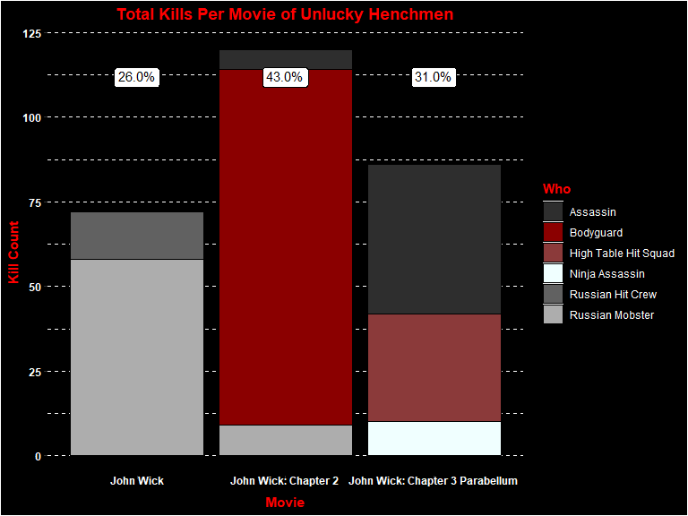

```r
ggplot(most_action) +
  aes(x = Movie, y = n, fill = Who) +
  geom_col(color = 'black') +
  geom_label(aes(label = percent(Percent), y = Inf), data = graph_labels, fill = 'white', vjust = 3) +
  labs(x = 'Movie', y = 'Kill Count', title = 'Total Kills Per Movie of Unlucky Henchmen') +
  scale_fill_manual(values = c('gray18', 'darkred', 'indianred4', 'azure1', 'gray38', 'gray68')) +
  theme(plot.background = element_rect(fill = 'black'),
        axis.text = element_text(color = 'white', face = 'bold'),
        axis.text.x = element_text(vjust = 5),
        title = element_text(color = 'red', face = 'bold'),
        legend.background = element_rect(fill = 'black'),
        legend.text = element_text(color = 'white'),
        plot.title = element_text(hjust = 0.5),
        panel.background = element_rect(fill = 'black'),
        panel.grid.major.x = element_blank(),
        panel.grid = element_line(linetype = 'dashed'))
```

The following shows the minutes of each film and the precise moments when action occurs. Between 25 and 50 minutes there is the most downtime. Chapter 2 and 3 share very similar trends with the first sections being more or less calm while the middle and later sections pickup. Chapter 1 has the alternate trend, most action being common place within the middle of the movie.

The handgun is the most popular weapon of choice with assault rifle, shotgun, and smg following close. Lesser known weapons are harder to see besides the mainstays of aresenal.

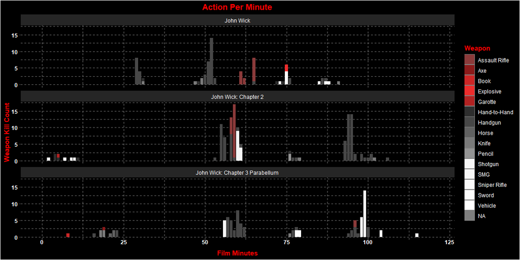

```r
ggplot(most_apm) +
  facet_wrap(~ Movie, nrow = 3) +
  aes(x = Minute, y = n, fill = Weapon) +
  geom_col() +
  labs(x = 'Film Minutes', y = 'Weapon Kill Count', title = 'Action Per Minute') +
  theme_dark() +
  scale_fill_manual(values = c('indianred4', 'firebrick4', 'firebrick3', 'firebrick2', 'firebrick', 'gray18', 'gray28', 'gray38', 'gray48', 'gray58', 'gray96', 'gray97', 'gray98', 'gray99', 'gray100')) +
  theme(plot.background = element_rect(fill = 'black'),
        axis.text = element_text(color = 'white', face = 'bold'),
        axis.text.x = element_text(vjust = 5),
        strip.text = element_text(color = 'white'),
        title = element_text(color = 'red', face = 'bold'),
        legend.background = element_rect(fill = 'black'),
        legend.text = element_text(color = 'white'),
        plot.title = element_text(hjust = 0.5),
        panel.background = element_rect(fill = 'black'),
        panel.grid = element_line(linetype = 'dashed'))
```

## Conclusions

Movie with most kills -> John Wick: Chapter 2

Most unlucky henchman -> Bodyguard from Chapter 2

Weapon of choice -> Handgun (across all films)